# Pedestrian/Auto Collisions

Alan K Jackson

May 8, 2018

[figure not shown]

## Pedestrian/Automobile Incidents in Harris County

Based on the [TxDOT](https://cris.dot.state.tx.us/public/Query/app/public/welcome) data from 2010 to 2017, I have analyzed incidents where pedestrians got hit by cars. First we will begin with some general statistics, and then bore down to some more specific items.

## CDC Data

From the website for the [Centers for Disease Control](https://www.cdc.gov/motorvehiclesafety/pedestrian_safety/index.html), we have the following information regrading Pedestrian incidents:  
Who is most at risk?

Older adults

Pedestrians ages 65 and older accounted for 19% of all pedestrian deaths and an estimated 13% of all pedestrians injured in 2015.

Children

In 2015, one in every five children under the age of 15 who were killed in traffic crashes were pedestrians.

Drivers and pedestrians who are alcohol-impaired

Almost half (48%) of crashes that resulted in pedestrian deaths involved alcohol for the driver or the pedestrian. One in every three (34%) of fatal pedestrian crashes involved a pedestrian with a blood alcohol concentration (BAC) of at least 0.08 grams per deciliter (g/dL) and 15% involved a driver with a BAC of at least 0.08 g/dL.

Additional Risk Factors

Additionally, higher vehicle speeds increase both the likelihood of a pedestrian being struck by a car and the severity of injury.

Most pedestrian deaths occur in urban areas, non-intersection locations, and at night.

## Injury Distribution

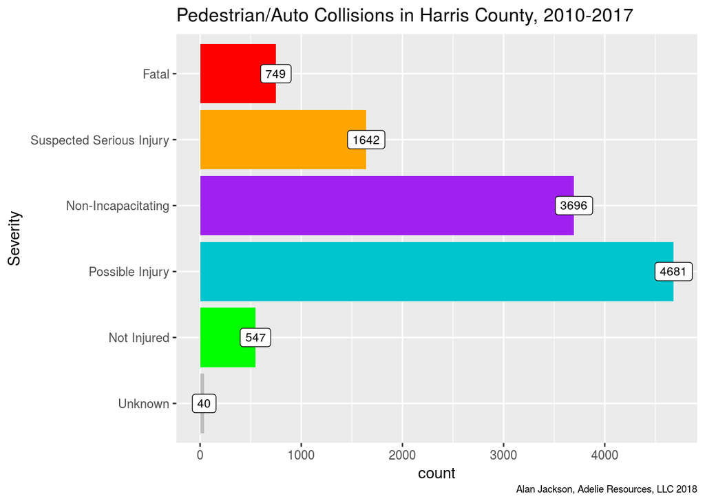

```r
peds %>%
  ggplot(aes(x=Severity)) +
  geom_bar(fill=SevereColor) +
  geom_label(aes(label=..count..), stat='count', size = 3) +
  coord_flip() +
  labs(title = "Pedestrian/Auto Collisions in Harris County, 2010-2017",
       caption = caption)
```

## Injuries as a function of road type

It seems obvious that if you get hit on the freeway, you are more likely to die, but let’s test that hypothesis, just to be sure.  
As the plot indicates, injuries on a highway are much more likely to be fatal, but most collisions occur on city streets.

But what the heck is this “non trafficway” category of road? I think it must mostly be parking lots, with a few driveways thrown in.

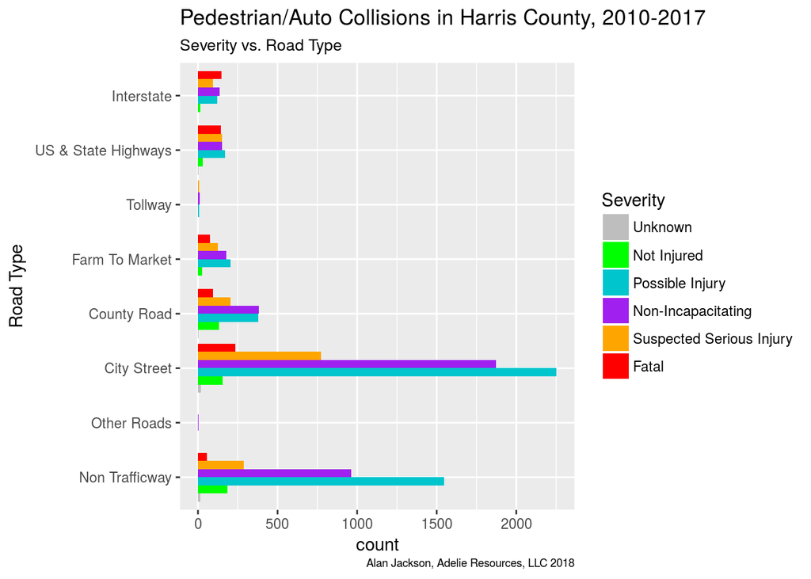

```r
peds %>% ggplot() +
  geom_bar(aes(x=RoadType, fill=Severity), position="dodge" ) +
  coord_flip() +
  scale_fill_manual("Severity",values = c("gray", "green", "turquoise3", "purple", "orange", "red")) +
  xlab("Road Type")+
  labs(title = "Pedestrian/Auto Collisions in Harris County, 2010-2017",
       subtitle = "Severity vs. Road Type",
       caption = caption) +
  theme(legend.position = "right")
```

## Data issues

The data is not perfect, there are a few issues. Not all of the locations make sense, and so cannot be linked to a latitude and longitude location, limiting the analysis to a degree. Only 70.5% of the data is geocoded.

## City Streets and Pedestrians

My primary interest is looking at city streets, to see where there may be hotspots, and to try to predict which spots are most likely to see a fatality or serious injury. So for now, I will restrict analysis to “City Streets”.

Let’s consider what time of day these incidents occur. I have heard it proposed that many incidents may be due to bars letting out and people wandering into the road in an impaired state. Or perhaps the driver is impaired.

Doesn’t look like impairment is a major factor. It appears that the incidents peak during rush hour. Well, there is a minor peak at 2 AM when the bars close. And an intriguing jump at 3 PM. Is that related to school letting out? I’ll have to look at that later.

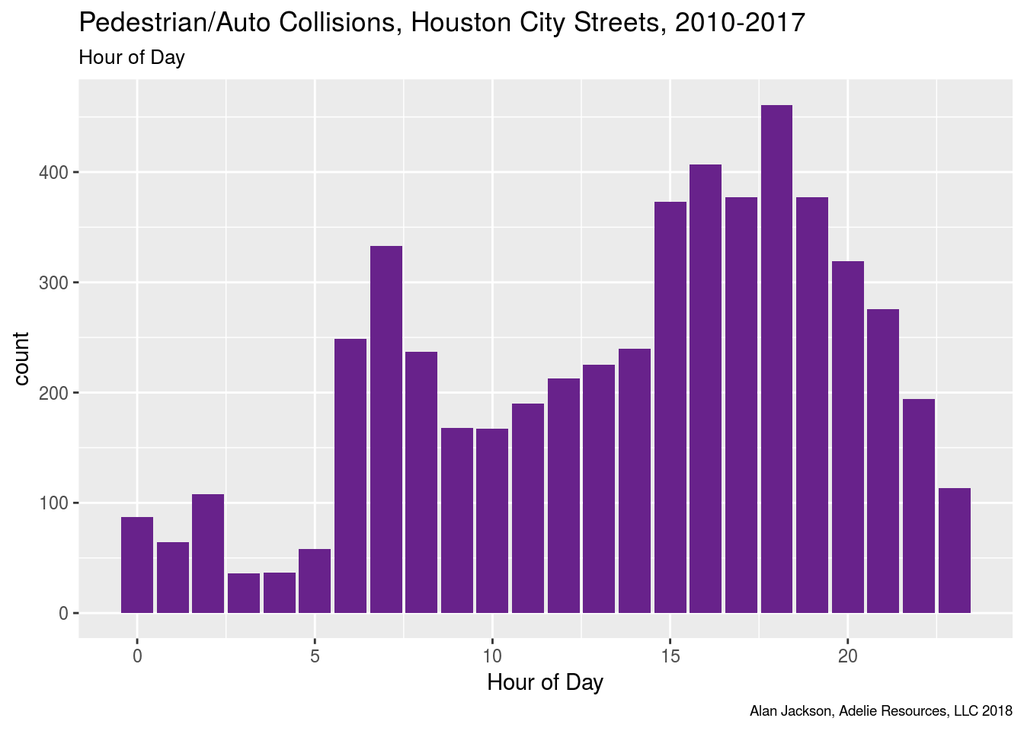

```r
citypeds <- peds %>% filter(RoadType=="City Street")
citypeds$Intersection <- as.factor(citypeds$Intersection)

citypeds %>% mutate(HourOfDay=hour(citypeds$Crash_DateTime)) %>%
  ggplot() +
  geom_bar(aes(x=HourOfDay), fill = "darkorchid4") +
  xlab("Hour of Day")+
  labs(title = "Pedestrian/Auto Collisions, Houston City Streets, 2010-2017",
       subtitle = "Hour of Day",
       caption = caption)
```

## Day of Week

How about day of the week? Not surprisingly, Sunday is the low day, and Saturday is rather low as well. Friday is the most dangerous day. Is that due to everyone being in a hurry? Drinking? Something else? Later we’ll examine the weekend effect with respect to location. Perhaps the drop represents not many people downtown on the weekend?

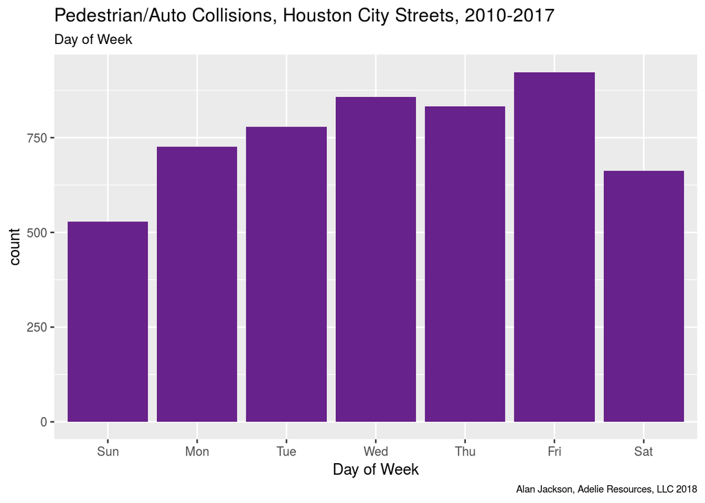

```r
citypeds %>% mutate(Daynum=wday(Crash_Date)) %>%
  ggplot(aes(x=wday(Daynum, label=TRUE))) +
  geom_bar(fill = "darkorchid4") +
  xlab("Day of Week")+
  labs(title = "Pedestrian/Auto Collisions, Houston City Streets, 2010-2017",
       subtitle = "Day of Week",
       caption = caption)
```

## Time of Year

There is a strong indication that there are fewer incidents during the summer than other times. Is that related to school being out? People on vacation? Maybe drivers are mellower during the summer? Certainly life is less hectic for commuters with kids - and the hours that people commute tend to change a bit with the season. But the large week-to-week scatter outside summer is puzzling. I have no idea what that means.

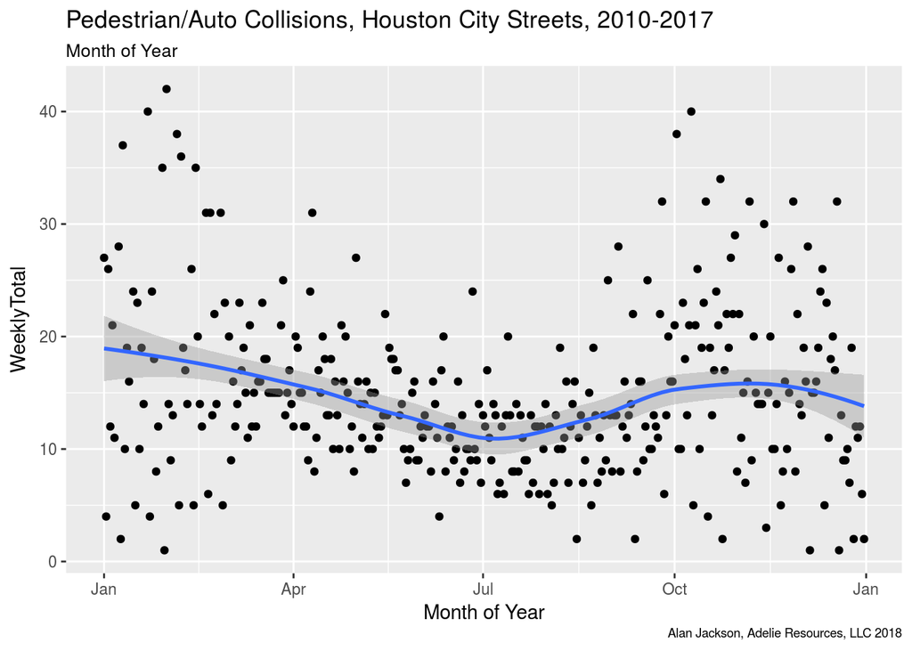

```r
citypeds %>% mutate(WkOfYear=as.Date(paste0("2000-",month(floor_date(Crash_Date, "week")),"-",day(floor_date(Crash_Date, "week")), "%Y-%m-%d"))) %>%
  group_by(WkOfYear) %>%
  summarise(WeeklyTotal=n()) %>%
  ggplot(aes(x=WkOfYear, y=WeeklyTotal)) +
  geom_point() +
  geom_smooth()  +
  scale_x_date(date_labels = "%b")+
  xlab("Month of Year") +
  labs(title = "Pedestrian/Auto Collisions, Houston City Streets, 2010-2017",
       subtitle = "Month of Year",
       caption = caption)
```

## Long-term trends - is it getting better?

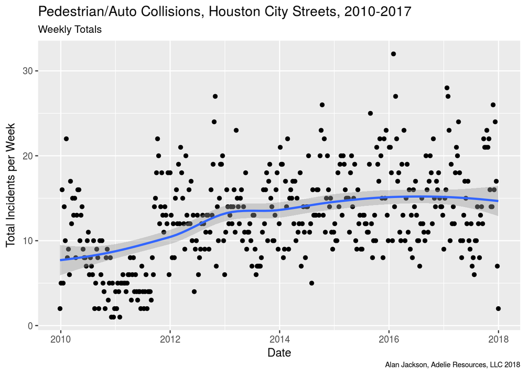

```r
citypeds %>% mutate(ByWeek=floor_date(Crash_Date, "week")) %>%
  group_by(ByWeek) %>%
  summarise(WeeklyTotal=n()) %>%
  ggplot(aes(x=ByWeek, y=WeeklyTotal)) +
  geom_point() +
  geom_smooth()  +
  xlab("Date") +
  ylab("Total Incidents per Week") +
  labs(title = "Pedestrian/Auto Collisions, Houston City Streets, 2010-2017",
       subtitle = "Weekly Totals",
       caption = caption)
```

## Where are the worst spots for number of incidents?

The worst is a location that has racked up 13 incidents in 7 years - about one incident every 6 months. 260 locations have seen two incidents, 81 locations have seen three. If one were looking for a way to prioritize work, this might be a good start.

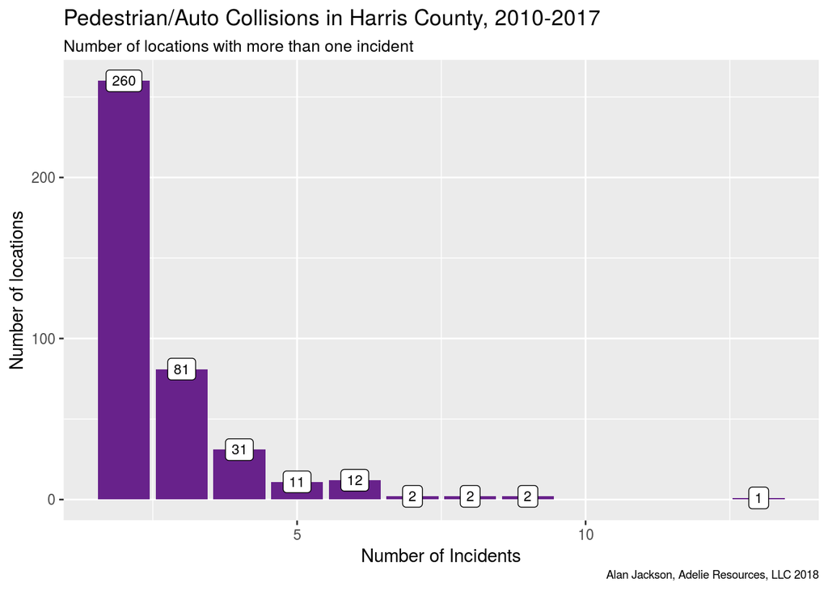

```r
citypedslatlng <- citypeds %>%
  filter(!is.na(Latitude)) %>%
  mutate(latlon=paste(as.character(Longitude), as.character(Latitude)))

badspots <- citypedslatlng %>%
  group_by(latlon) %>%
  summarise(total=n()) %>%
  filter(total>1)

badspots %>%
  ggplot(aes(x=total)) +
  geom_bar(fill = "darkorchid4") +
  geom_label(aes(label=..count..), stat='count', size = 3) +
  labs(title = "Pedestrian/Auto Collisions in Harris County, 2010-2017",
       subtitle = "Number of locations with more than one incident",
       caption = caption) +
    xlab("Number of Incidents")+
    ylab("Number of locations")
```

## What controls the Severity?

What controls how serious an incident turns out to be? Most probably the speed of the vehicle. So let’s take a look at that.

Not as clear as one might think. Certainly serious injuries rise with speed, and slight (non-incapacitating) injuries fall, so that fits with expectations. But not injured stays flat - surprisingly. Fatal also is flat - but the numbers are so small that that may not be significant.

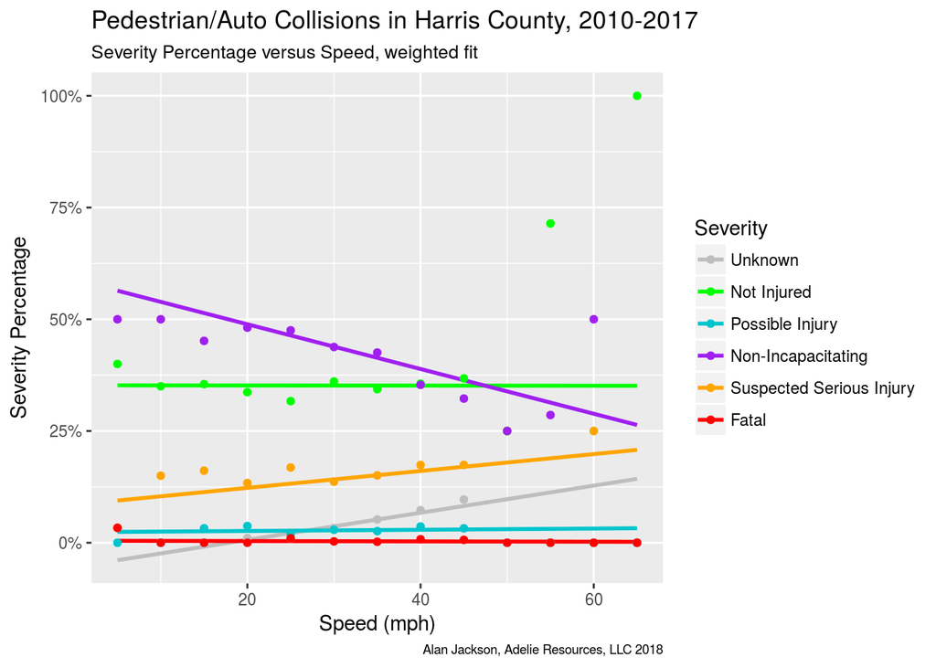

```r
#   round speed to nearest 5 mph

citypeds %>% mutate(speed=as.integer((Crash_Speed_Limit+2.5)/5)*5) %>%
  filter(speed>0) %>%
  group_by(speed) %>%
  summarise(totbyspeed=n(),
            fatal=sum(Crash_Sev_ID==4),
            serious=sum(Crash_Sev_ID==1),
            injury=sum(Crash_Sev_ID==2),
            maybe=sum(Crash_Sev_ID==3),
            okay=sum(Crash_Sev_ID==5),
            unk=sum(Crash_Sev_ID==0)) %>%
  mutate(fatalpct=fatal/totbyspeed,
         seriouspct=serious/totbyspeed,
         injurypct=injury/totbyspeed,
         maybepct=maybe/totbyspeed,
         okaypct=okay/totbyspeed,
         unkpct=unk/totbyspeed
         ) %>%
  select(speed, totbyspeed, fatalpct:unkpct) %>%
  rename(Fatal=fatalpct, Serious_Injury=seriouspct,  Non_Incapacitating=injurypct, Possible_Injury=maybepct, Not_Injured=okaypct, Unknown=unkpct) %>%
  gather(Severity, Pct, Fatal:Unknown) %>%
  ggplot() +
  geom_smooth(aes(x=speed, y=Pct, color=Severity, weight=totbyspeed), se=FALSE, method='lm')+
  geom_point(aes(x=speed, y=Pct, color=Severity))+
  scale_color_manual("Severity",values = c("gray", "green", "turquoise3", "purple", "orange", "red"), labels=c("Unknown", "Not Injured", "Possible Injury", "Non-Incapacitating", "Suspected Serious Injury", "Fatal")) +
labs(title = "Pedestrian/Auto Collisions in Harris County, 2010-2017",
       subtitle = "Severity Percentage versus Speed, weighted fit",
       caption = caption) +
    xlab("Speed (mph)")+
    ylab("Severity Percentage") +
    scale_y_continuous(labels=scales::percent) +
  theme(legend.position = "right")
```

## Does the number of incidents predict fatalities?

Do you prioritize improving locations where there has been a fatality? Or do you prioritize by number of incidents - even if none of them were serious. To get a handle on this, let’s look at whether or not the number of incidents is related to the number of serious incidents.  
Looks pretty ambiguous to me. Note that for greater than about 6 incidents, the statistics are pretty poor, as this table illustrates.

```r
mytable <- citypedslatlng %>%
  group_by(latlon) %>%
  summarise(incidents_per_location=n()) %>%
  group_by(incidents_per_location) %>%
  summarise(total_incidents=sum(incidents_per_location))

print(xtable(mytable), type="html")
```

|  | incidents_per_location | total_incidents |
| --- | --- | --- |
| 1 | 1 | 4151 |
| 2 | 2 | 520 |
| 3 | 3 | 243 |
| 4 | 4 | 124 |
| 5 | 5 | 55 |
| 6 | 6 | 72 |
| 7 | 7 | 14 |
| 8 | 8 | 16 |
| 9 | 9 | 18 |
| 10 | 13 | 13 |

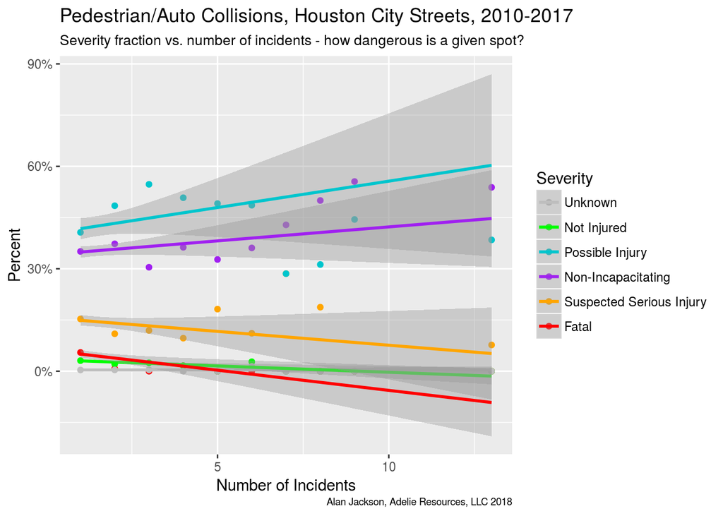

```r
badspots <- citypedslatlng %>%
  group_by(latlon) %>%
  summarise(total=n())

badspots <- citypedslatlng %>%
  group_by(latlon) %>%
  summarise(total=n(),
            fatal=sum(Crash_Sev_ID==4),
            serious=sum(Crash_Sev_ID==1),
            injury=sum(Crash_Sev_ID==2),
            maybe=sum(Crash_Sev_ID==3),
            okay=sum(Crash_Sev_ID==5),
            unk=sum(Crash_Sev_ID==0)) %>%
  group_by(total) %>%
  summarise(totalsum=sum(total),
            fatal=sum(fatal)/totalsum,
            serious=sum(serious)/totalsum,
            injury=sum(injury)/totalsum,
            maybe=sum(maybe)/totalsum,
            okay=sum(okay)/totalsum,
            unk=sum(unk)/totalsum) %>%
  gather(Severity, SumSevere, fatal:unk)

badspots$Severity <-  factor(badspots$Severity, levels=c("unk", "okay", "maybe", "injury", "serious", "fatal"))

badspots %>%
  ggplot() +
  geom_point(aes(x=total, y=SumSevere, color=Severity)) +
  #geom_bar(aes(x=total, fill=Severity), stat='identity', position="dodge")
  geom_smooth(aes(x=total, y=SumSevere, color=Severity, weight=totalsum), method='lm', formula=y~x, se=TRUE)  +
  xlab("Number of Incidents") +
  ylab("Percent") +
  scale_y_continuous(labels=scales::percent) +
  scale_color_manual("Severity",values = c("gray", "green", "turquoise3", "purple", "orange", "red"), labels=c("Unknown", "Not Injured", "Possible Injury", "Non-Incapacitating", "Suspected Serious Injury", "Fatal")) +
  labs(title = "Pedestrian/Auto Collisions, Houston City Streets, 2010-2017",
       subtitle = "Severity fraction vs. number of incidents - how dangerous is a given spot?",
       caption = caption) +
  theme(legend.position = "right")
```

## What about Jaywalking?

Is there a pattern related to where the incident took place? At an intersection, or somewhere else? Generally, pedestrians are supposed to cross streets at corners - perhaps that is a factor?  
It looks like nearly half of the incidents may be related to jaywalking! Now, that does not of necessity place blame on the victim. There are many locations which are far from an intersection, and due to poor design, pedestrians are encouraged by the design to cross where they should not.

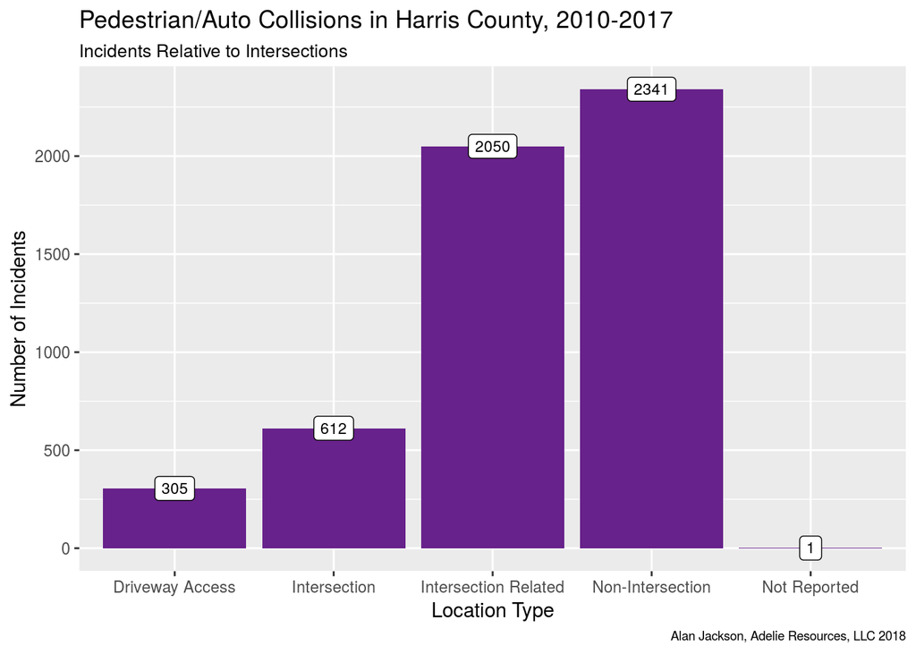

```r
citypeds %>%
  ggplot(aes(x=Intersection)) +
  geom_bar(fill = "darkorchid4") +
  geom_label(aes(label=..count..), stat='count', size = 3) +
  labs(title = "Pedestrian/Auto Collisions in Harris County, 2010-2017",
       subtitle = "Incidents Relative to Intersections",
       caption = caption) +
    xlab("Location Type")+
    ylab("Number of Incidents")
```

## How does the type of crossing relate to the injury severity?

It looks bad to not cross at an intersection. Ceertainly away from an intersection an automobile is more likely to be traveling at the speed limit (or above), and also is not likely to expect to see a pedestrian.

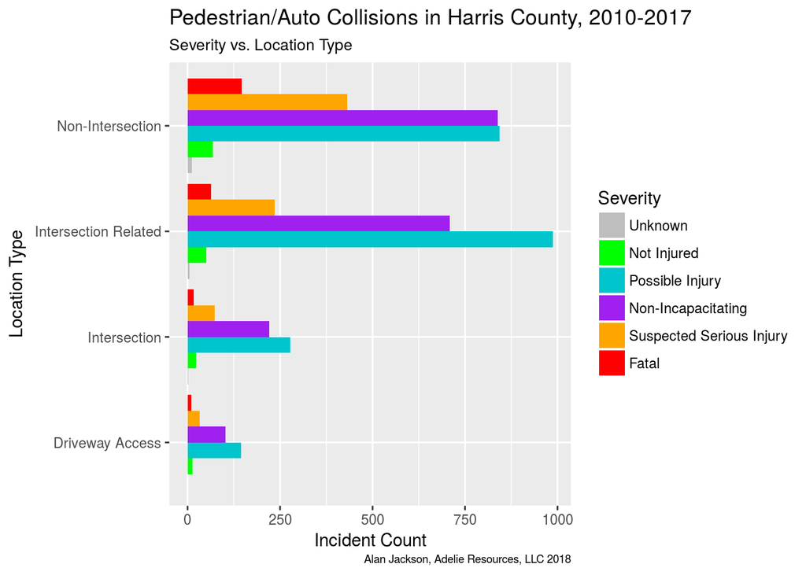

```r
citypeds %>% filter(Intersection!="Not Reported") %>%
  ggplot() +
  geom_bar(aes(x=Intersection, fill=Severity), position="dodge" ) +
  coord_flip() +
  scale_fill_manual("Severity",values = c("gray", "green", "turquoise3", "purple", "orange", "red")) +
  xlab("Location Type")+
  ylab("Incident Count")+
  labs(title = "Pedestrian/Auto Collisions in Harris County, 2010-2017",
       subtitle = "Severity vs. Location Type",
       caption = caption) +
  theme(legend.position = "right")
```

## Another look at location type and injury severity

Here we see quite clearly - after consolidating “Intersection Related” and “Intersection” together - that not being at an intersection is much more dangerous. The likelihood of serious injury or death is about 50% greater at non-intersections.

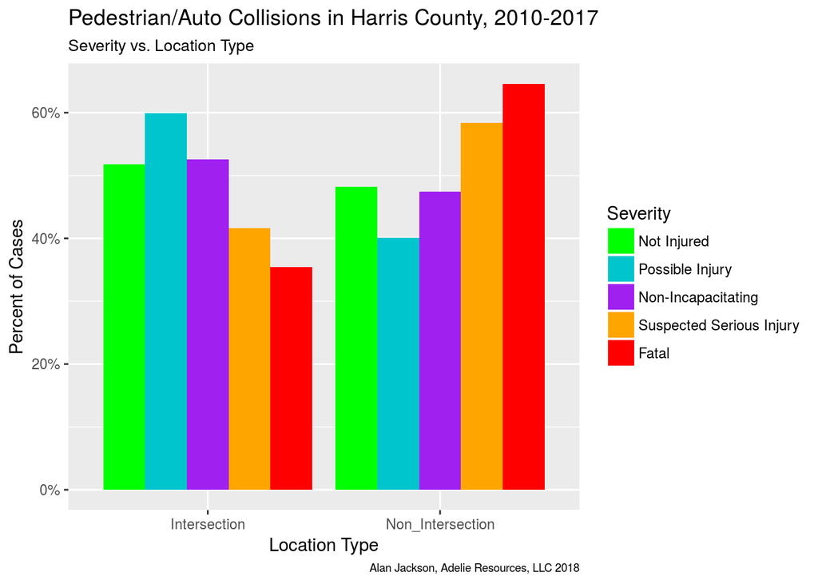

```r
citypeds %>%
  filter(Severity!="Unknown") %>%
  group_by(Severity, Intersection) %>%
  summarise(total=n()) %>%
  mutate(Intersection=gsub(" ", "_", Intersection, fixed=TRUE)) %>%
  mutate(Intersection=gsub("-", "_", Intersection, fixed=TRUE)) %>%
  spread(Intersection,total) %>%
  mutate(mysum=(Intersection + Intersection_Related + Non_Intersection)) %>%
  mutate(Intersection=Intersection + Intersection_Related,
  Intersection=Intersection/mysum, Non_Intersection=Non_Intersection/mysum) %>%
  select(Severity, Intersection, Non_Intersection) %>%
  gather(Location, Probability, -Severity) %>%
  ggplot(aes(x=Location, y=Probability)) +
  geom_bar(aes(fill=Severity), position="dodge", stat='identity') +
   scale_fill_manual("Severity",values = c("green", "turquoise3", "purple", "orange", "red")) +
  xlab("Location Type")+
  ylab("Percent of Cases")+
  scale_y_continuous(labels=scales::percent) +
  labs(title = "Pedestrian/Auto Collisions in Harris County, 2010-2017",
       subtitle = "Severity vs. Location Type",
       caption = caption) +
  theme(legend.position = "right")
```

## What about speed at non-intersections?

We saw that speed versus severity did not show a tremendously robust result, but perhaps if we look only at the non-intersection data. After all, near an intersection, cars will often be going much slower than the speed limit.  
I see some effect, it does enhance the tradeoff between non-incapacitating injuries and serious injuries.

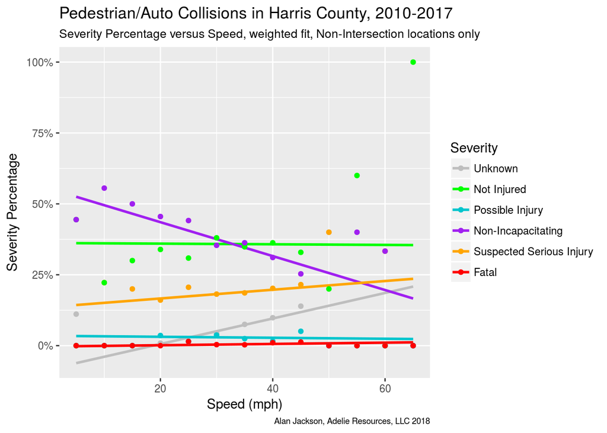

```r
#   round speed to nearest 5 mph

citypeds %>% mutate(speed=as.integer((Crash_Speed_Limit+2.5)/5)*5) %>%
  filter(speed>0) %>%
  filter(Intersection=="Non-Intersection") %>%
  group_by(speed) %>%
  summarise(totbyspeed=n(),
            fatal=sum(Crash_Sev_ID==4),
            serious=sum(Crash_Sev_ID==1),
            injury=sum(Crash_Sev_ID==2),
            maybe=sum(Crash_Sev_ID==3),
            okay=sum(Crash_Sev_ID==5),
            unk=sum(Crash_Sev_ID==0)) %>%
  mutate(fatalpct=fatal/totbyspeed,
         seriouspct=serious/totbyspeed,
         injurypct=injury/totbyspeed,
         maybepct=maybe/totbyspeed,
         okaypct=okay/totbyspeed,
         unkpct=unk/totbyspeed
         ) %>%
  select(speed, totbyspeed, fatalpct:unkpct) %>%
  rename(Fatal=fatalpct, Serious_Injury=seriouspct,  Non_Incapacitating=injurypct, Possible_Injury=maybepct, Not_Injured=okaypct, Unknown=unkpct) %>%
  gather(Severity, Pct, Fatal:Unknown) %>%
  ggplot() +
  geom_smooth(aes(x=speed, y=Pct, color=Severity, weight=totbyspeed), se=FALSE, method='lm')+
  geom_point(aes(x=speed, y=Pct, color=Severity))+
  scale_color_manual("Severity",values = c("gray", "green", "turquoise3", "purple", "orange", "red"), labels=c("Unknown", "Not Injured", "Possible Injury", "Non-Incapacitating", "Suspected Serious Injury", "Fatal")) +
labs(title = "Pedestrian/Auto Collisions in Harris County, 2010-2017",
       subtitle = "Severity Percentage versus Speed, weighted fit, Non-Intersection locations only",
       caption = caption) +
    xlab("Speed (mph)")+
    ylab("Severity Percentage") +
  scale_y_continuous(labels=scales::percent) +
  theme(legend.position = "right")
```

## Subset exploration - Injury vs. Time of Day

It appears that less serious injuries largely occur during rush hour - 6-8 AM and 3-7 PM - while serious injuries and fatalities tend to occur later in the day, more like 6-10 PM. Is the interesting peak in fatalities at 6 AM due to less traffic, so cars can travel faster at that hour than later in the day?

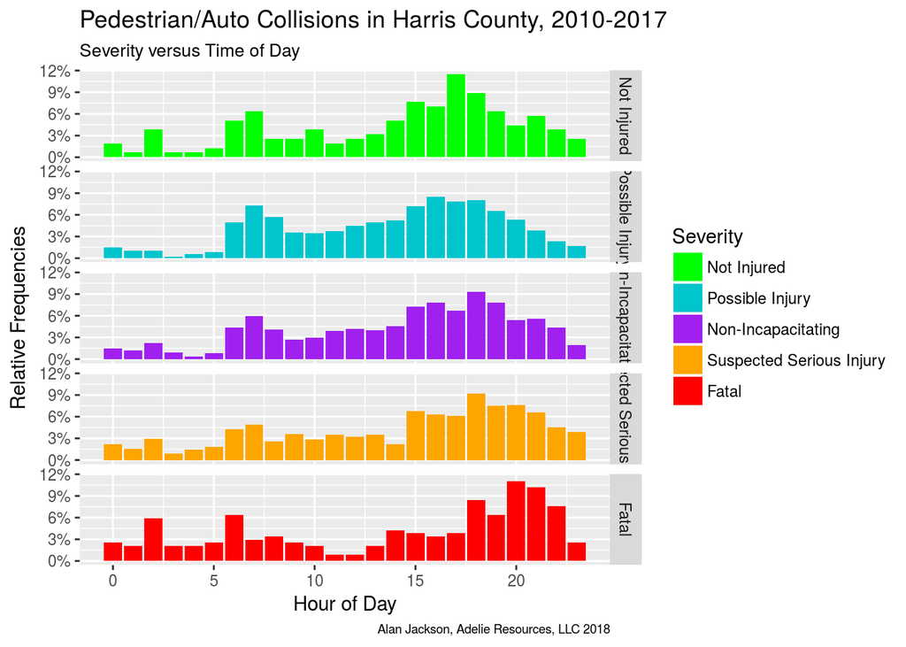

```r
citypeds %>% mutate(HourOfDay=hour(Crash_DateTime)) %>%
  mutate(Daynum=wday(Crash_Date)) %>%
  mutate(MonOfYear=month(Crash_Date)) %>%
  filter(Severity!="Unknown") %>%
  select(Severity, HourOfDay, Daynum, MonOfYear) %>%
  ggplot(aes(x=HourOfDay)) +
  geom_bar(aes(y = ..prop.., fill=Severity), stat="count") +
  facet_grid(Severity~.) +
  scale_y_continuous(labels=scales::percent) +
  scale_fill_manual(values = c("green", "turquoise3", "purple", "orange", "red")) +
labs(title = "Pedestrian/Auto Collisions in Harris County, 2010-2017",
       subtitle = "Severity versus Time of Day",
       caption = caption) +
    xlab("Hour of Day")+
    ylab("Relative Frequencies") +
  theme(legend.position = "right")
```

## Subset exploration - Injury vs. Day of Week

All of the injury categories mirror each other, showing lower values on the weekend and higher values during the week. Except fatalities. There the pattern is reversed, with the largest percentages being on Saturday and Sunday. Is that due to the 2 AM spike?

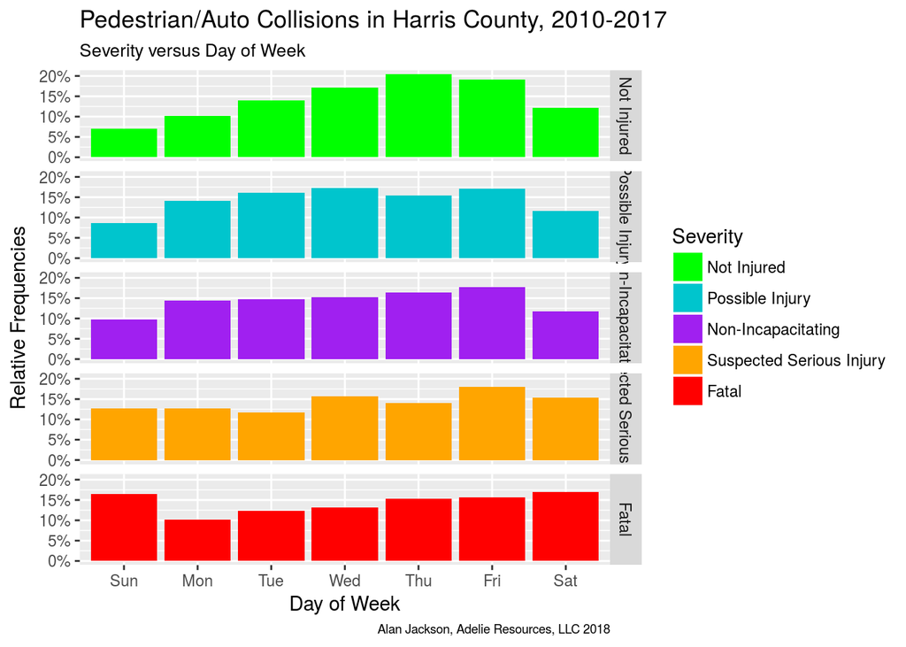

```r
citypeds %>% mutate(HourOfDay=hour(Crash_DateTime)) %>%
  mutate(Daynum=wday(Crash_Date)) %>%
  mutate(MonOfYear=month(Crash_Date)) %>%
  filter(Severity!="Unknown") %>%
  select(Severity, HourOfDay, Daynum, MonOfYear) %>%
  ggplot(aes(x=wday(Daynum, label=TRUE))) +
  geom_bar(aes(group=factor(0), y = ..prop.., fill=Severity), stat="count") +
  facet_grid(Severity~.) +
  scale_y_continuous(labels=scales::percent) +
  scale_fill_manual(values = c("green", "turquoise3", "purple", "orange", "red")) +
labs(title = "Pedestrian/Auto Collisions in Harris County, 2010-2017",
       subtitle = "Severity versus Day of Week",
       caption = caption) +
    xlab("Day of Week")+
    ylab("Relative Frequencies") +
  theme(legend.position = "right")
```

## Exploration of Fatalities by Day and Hour

The numbers are getting small, so the statistics are getting suspect, but it does appear tha the Sunday spike in fatalities is dominated by the early hours - Saturday night really. The Saturday spike has a small increase at 2 AM, but also a significant late night component. I would guess that alcohol is involved - either for the driver or the pedestrian, or both.

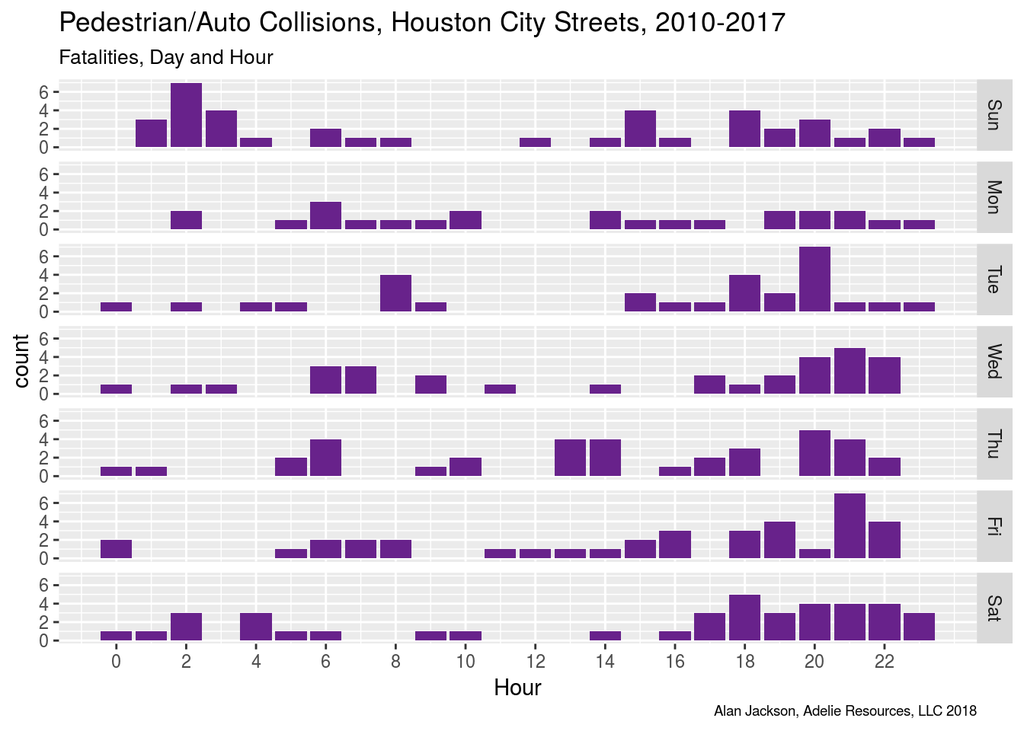

```r
citypeds %>% mutate(Day=wday(Crash_DateTime, label=TRUE), Hour=hour(Crash_DateTime)) %>%
  filter(Severity=="Fatal") %>%
  ggplot() +
  geom_bar(aes(x=Hour), fill = "darkorchid4") +
  facet_grid(Day~.) +
  xlab("Hour") +
  scale_x_continuous(breaks=seq(0,23,2)) +
  labs(title = "Pedestrian/Auto Collisions, Houston City Streets, 2010-2017",
       subtitle = "Fatalities, Day and Hour",
       caption = caption) +
  theme(legend.position = "bottom")
```

## Subset exploration - Injury vs. Month of Year

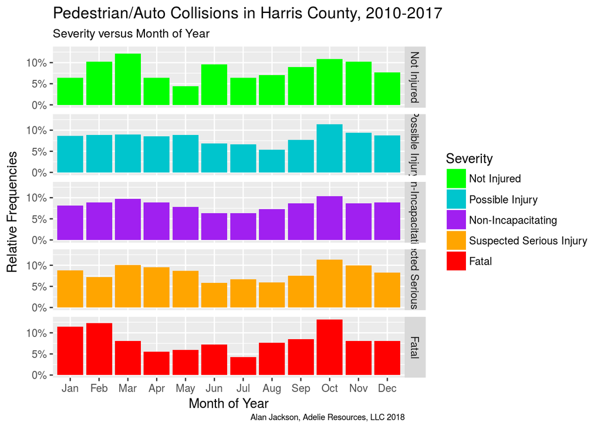

```r
citypeds %>% mutate(HourOfDay=hour(Crash_DateTime)) %>%
  mutate(Daynum=wday(Crash_Date)) %>%
  mutate(MonOfYear=month(Crash_Date, label=TRUE, abbr=TRUE)) %>%
  filter(Severity!="Unknown") %>%
  select(Severity, HourOfDay, Daynum, MonOfYear) %>%
  ggplot(aes(x=MonOfYear)) +
  geom_bar(aes(group=factor(0), y = ..prop.., fill=Severity), stat="count") +
  facet_grid(Severity~.) +
  scale_y_continuous(labels=scales::percent) +
  scale_fill_manual(values = c("green", "turquoise3", "purple", "orange", "red")) +
labs(title = "Pedestrian/Auto Collisions in Harris County, 2010-2017",
       subtitle = "Severity versus Month of Year",
       caption = caption) +
    xlab("Month of Year")+
    ylab("Relative Frequencies") +
  theme(legend.position = "right")
```

## Subset exploration - Injury vs. Date

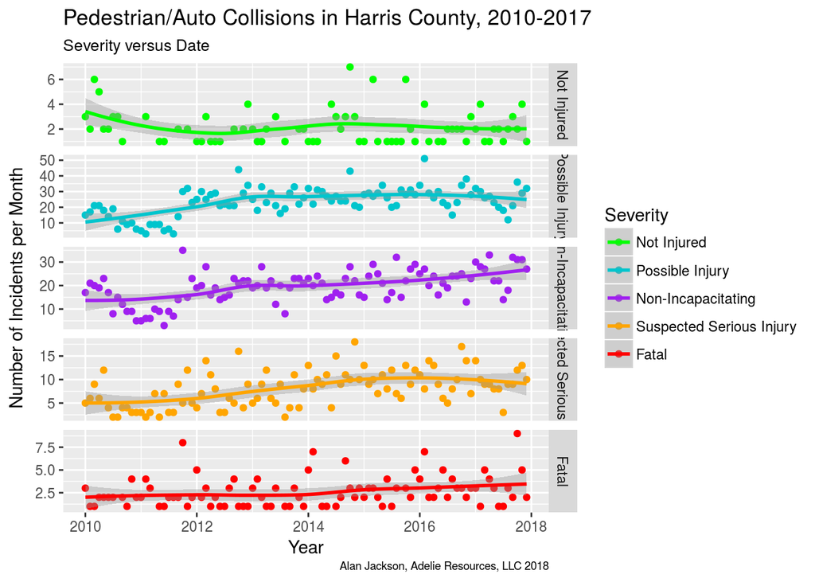

```r
citypeds %>%
  filter(Severity!="Unknown") %>%
  select(Severity, Crash_Date) %>%
  mutate(ByWeek=floor_date(Crash_Date, "month")) %>%
  group_by(ByWeek, Severity) %>%
  summarise(WeeklyTotal=n()) %>%
  mutate(Percent=WeeklyTotal/sum(WeeklyTotal)) %>%
  ggplot() +
  geom_point(aes(x=ByWeek, y=WeeklyTotal, color=Severity)) +
  geom_smooth(aes(x=ByWeek, y=WeeklyTotal, color=Severity))  +
  facet_grid(Severity~., scales="free") +
  scale_color_manual("Severity",values = c("green", "turquoise3", "purple", "orange", "red"), labels=c("Not Injured", "Possible Injury", "Non-Incapacitating", "Suspected Serious Injury", "Fatal")) +
labs(title = "Pedestrian/Auto Collisions in Harris County, 2010-2017",
       subtitle = "Severity versus Date",
       caption = caption) +
    xlab("Year")+
    ylab("Number of Incidents per Month") +
  theme(legend.position = "right")
```

## Brief Interlude to consider Parking Lots

Let’s take a break from city streets to consider Non-Trafficways.

## Non-Trafficways, Time of Day

Not surprisingly, parking lots are especially dangerous when most used - in the middle of the day.

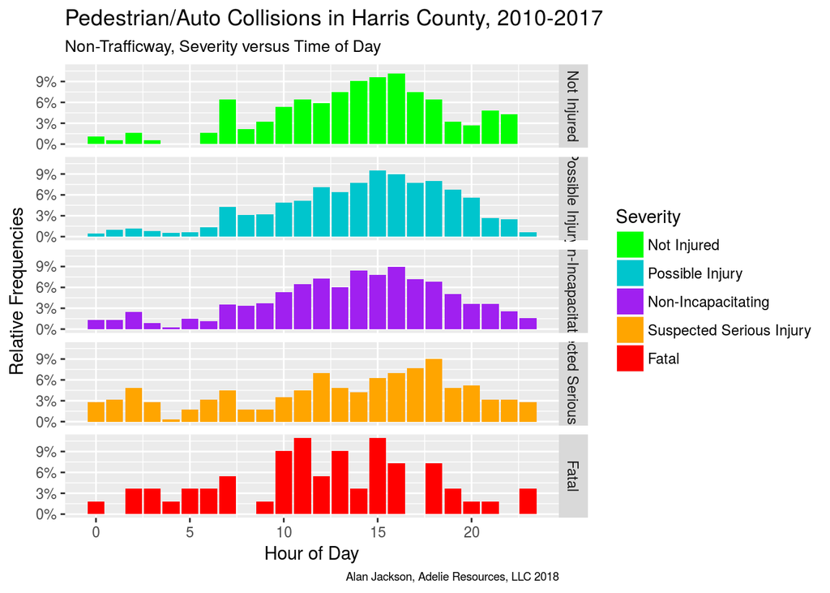

```r
parkingpeds <- peds %>% filter(RoadType=="Non Trafficway")
parkingpeds %>% mutate(HourOfDay=hour(Crash_DateTime)) %>%
  mutate(Daynum=wday(Crash_Date)) %>%
  mutate(MonOfYear=month(Crash_Date)) %>%
  filter(Severity!="Unknown") %>%
  select(Severity, HourOfDay, Daynum, MonOfYear) %>%
  ggplot(aes(x=HourOfDay)) +
  geom_bar(aes(y = ..prop.., fill=Severity), stat="count") +
  facet_grid(Severity~.) +
  scale_y_continuous(labels=scales::percent) +
  scale_fill_manual(values = c("green", "turquoise3", "purple", "orange", "red")) +
labs(title = "Pedestrian/Auto Collisions in Harris County, 2010-2017",
       subtitle = "Non-Trafficway, Severity versus Time of Day",
       caption = caption) +
    xlab("Hour of Day")+
    ylab("Relative Frequencies") +
  theme(legend.position = "right")
```

## Non-Trafficways, Day of Week

Hard to say that there is much dependence on day of week. Note that the numbers of fatalities are small, so for that row we may be seeing statistical fluctuation.

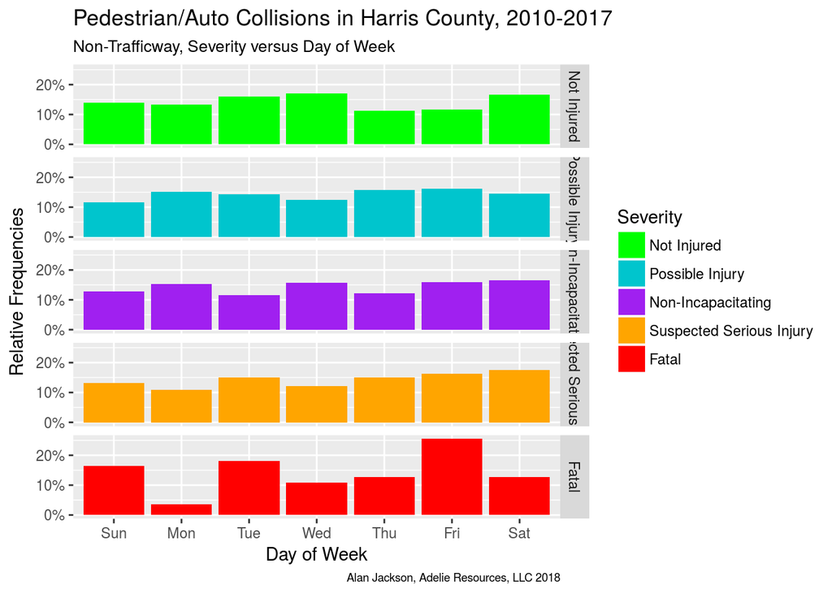

```r
parkingpeds %>% mutate(HourOfDay=hour(Crash_DateTime)) %>%
  mutate(Daynum=wday(Crash_Date)) %>%
  mutate(MonOfYear=month(Crash_Date)) %>%
  filter(Severity!="Unknown") %>%
  select(Severity, HourOfDay, Daynum, MonOfYear) %>%
  ggplot(aes(x=wday(Daynum, label=TRUE))) +
  geom_bar(aes(group=factor(0), y = ..prop.., fill=Severity), stat="count") +
  facet_grid(Severity~.) +
  scale_y_continuous(labels=scales::percent) +
  scale_fill_manual(values = c("green", "turquoise3", "purple", "orange", "red")) +
labs(title = "Pedestrian/Auto Collisions in Harris County, 2010-2017",
       subtitle = "Non-Trafficway, Severity versus Day of Week",
       caption = caption) +
    xlab("Day of Week")+
    ylab("Relative Frequencies") +
  theme(legend.position = "right")
```

## Non-Trafficways, Month of Year

No obvious patterns to me.

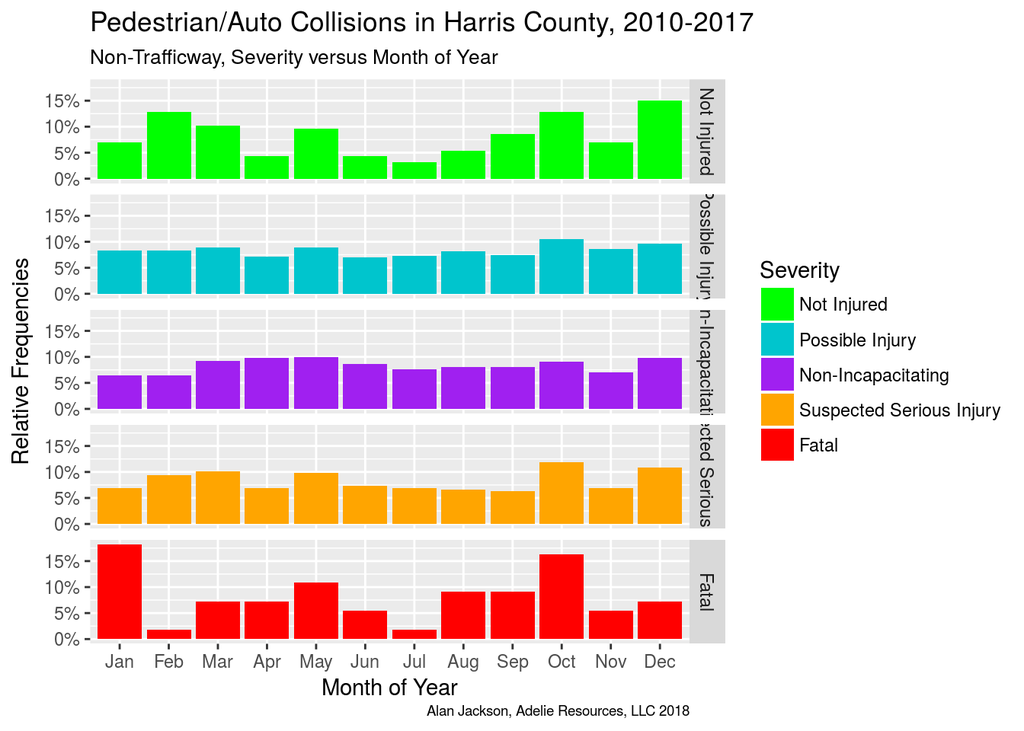

```r
parkingpeds %>% mutate(HourOfDay=hour(Crash_DateTime)) %>%
  mutate(Daynum=wday(Crash_Date)) %>%
  mutate(MonOfYear=month(Crash_Date, label=TRUE, abbr=TRUE)) %>%
  filter(Severity!="Unknown") %>%
  select(Severity, HourOfDay, Daynum, MonOfYear) %>%
  ggplot(aes(x=MonOfYear)) +
  geom_bar(aes(group=factor(0), y = ..prop.., fill=Severity), stat="count") +
  facet_grid(Severity~.) +
  scale_y_continuous(labels=scales::percent) +
  scale_fill_manual(values = c("green", "turquoise3", "purple", "orange", "red")) +
labs(title = "Pedestrian/Auto Collisions in Harris County, 2010-2017",
       subtitle = "Non-Trafficway, Severity versus Month of Year",
       caption = caption) +
    xlab("Month of Year")+
    ylab("Relative Frequencies") +
  theme(legend.position = "right")
```

## Non-Trafficways, Date

Interestingly, we see the same trend in the non-trafficway data as in the city street data. Is this related to cell-phone distracted pedestrians? Improved economy? Hard to say.

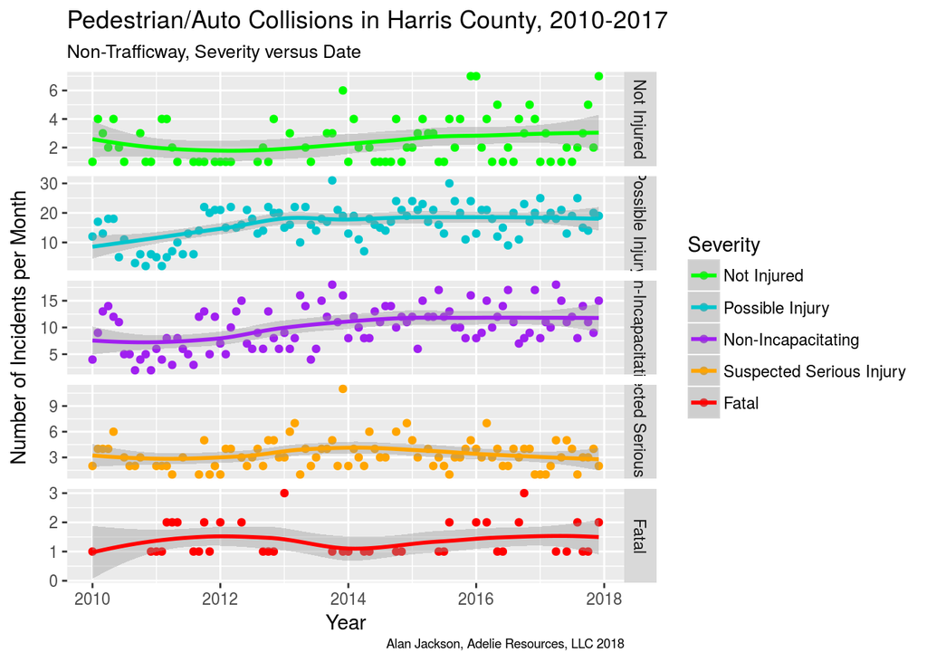

```r
parkingpeds %>%
  filter(Severity!="Unknown") %>%
  select(Severity, Crash_Date) %>%
  mutate(ByWeek=floor_date(Crash_Date, "month")) %>%
  group_by(ByWeek, Severity) %>%
  summarise(WeeklyTotal=n()) %>%
  mutate(Percent=WeeklyTotal/sum(WeeklyTotal)) %>%
  ggplot() +
  geom_point(aes(x=ByWeek, y=WeeklyTotal, color=Severity)) +
  geom_smooth(aes(x=ByWeek, y=WeeklyTotal, color=Severity))  +
  facet_grid(Severity~., scales="free") +
  scale_color_manual("Severity",values = c("green", "turquoise3", "purple", "orange", "red"), labels=c("Not Injured", "Possible Injury", "Non-Incapacitating", "Suspected Serious Injury", "Fatal")) +
labs(title = "Pedestrian/Auto Collisions in Harris County, 2010-2017",
       subtitle = "Non-Trafficway, Severity versus Date",
       caption = caption) +
    xlab("Year")+
    ylab("Number of Incidents per Month") +
  theme(legend.position = "right")
```

```r
badspots <-
  citypedslatlng %>%
  group_by(latlon, Rpt_Street_Name, Severity) %>%
  summarise(total=n())

# Locations with 5 or more incidents
mytable <-  citypedslatlng %>%
  group_by(latlon, Rpt_Street_Name) %>%
  summarise(total=n()) %>%
  filter(total>4) %>%
  arrange(desc(total)) %>%
  select(Street=Rpt_Street_Name, Total=total)
print(xtable(mytable), type="html")
```

|  | latlon | Street | Total |
| --- | --- | --- | --- |
| 1 | -95.38210309 29.73359481 | FANNIN | 8 |
| 2 | -95.44547307 29.74168481 | WESTHEIMER | 8 |
| 3 | -95.36146309 29.7548648 | MCKINNEY | 7 |
| 4 | -95.39127308 29.74465481 | WESTHEIMER | 7 |
| 5 | -95.39115308 29.73455481 | RICHMOND | 6 |
| 6 | -95.39127308 29.74465481 | MONTROSE | 6 |
| 7 | -95.47339306 29.84879479 | ANTOINE | 6 |
| 8 | -95.53805305 29.70509482 | BELLAIRE | 6 |
| 9 | -95.54533305 29.70482482 | BELLAIRE | 6 |
| 10 | -95.55365304 29.67502482 | BISSONNET | 6 |
| 11 | -95.36853309 29.7491748 | SAN JACINTO | 5 |
| 12 | -95.38464308 29.85938478 | AIRLINE | 5 |
| 13 | -95.50303306 29.68977482 | BISSONNET | 5 |

```r
#   Pull out Peds with geocoding
#peds <- peds %>% filter(!is.na(Latitude))

#   Create a lat/long hash to group on
#peds <- peds %>%
#  mutate(latlon=paste(as.character(Longitude), as.character(Latitude)))
```